# Supervised machine learning

Ryan Wesslen

June 15, 2017

### Supervised machine learning

We’ll be working with tweets from the four major US presidential candidates’ Twitter accounts.

Let’s create an algorithm to determine what words most distinctively are used by Donald Trump relative to Ted Cruz.

This example was created from workshop materials created by Pablo Barbera.

```r
#set your personal working directory if you're running as chunks
#setwd("~/Dropbox/fall-2016-pm-twitter-text/")

tweets <- read.csv("../datasets/pres-tweets.csv", stringsAsFactors = F)
tweets <- subset(tweets, displayName %in% c("Donald J. Trump","Ted Cruz"))
tweets$trump <- ifelse(tweets$displayName=="Donald J. Trump", 0, 1)
```

We’ll do some cleaning as well – substituting handles with @. Why? We want to provent overfitting.

```r
tweets$body <- gsub('@[0-9_A-Za-z]+', '@', tweets$body)
```

```r
# updated for quanteda 0.9.9.50
library(quanteda)
twcorpus <- corpus(tweets$body)
twdfm <- dfm(twcorpus,
             remove=c(stopwords("english"), "t.co", "https", "rt", "amp", "http", "t.c", "can"),
             remove_numbers = TRUE,
             remove_symbols = TRUE,
             remove_url = TRUE
             )
twdfm <- dfm_trim(twdfm, min_count = 10)
```

And split the dataset into training and test set. We’ll go with 80% training and 20% set. Note the use of a random seed to make sure our results are replicable.

```r
set.seed(123)
training <- sample(1:nrow(tweets), floor(.80 * nrow(tweets)))
test <- (1:nrow(tweets))[1:nrow(tweets) %in% training == FALSE]
```

Our first step is to train the classifier using cross-validation. There are many packages in R to run machine learning models. For regularized regression, glmnet is in my opinion the best. It’s much faster than caret or mlr (in my experience at least), and it has cross-validation already built-in, so we don’t need to code it from scratch.

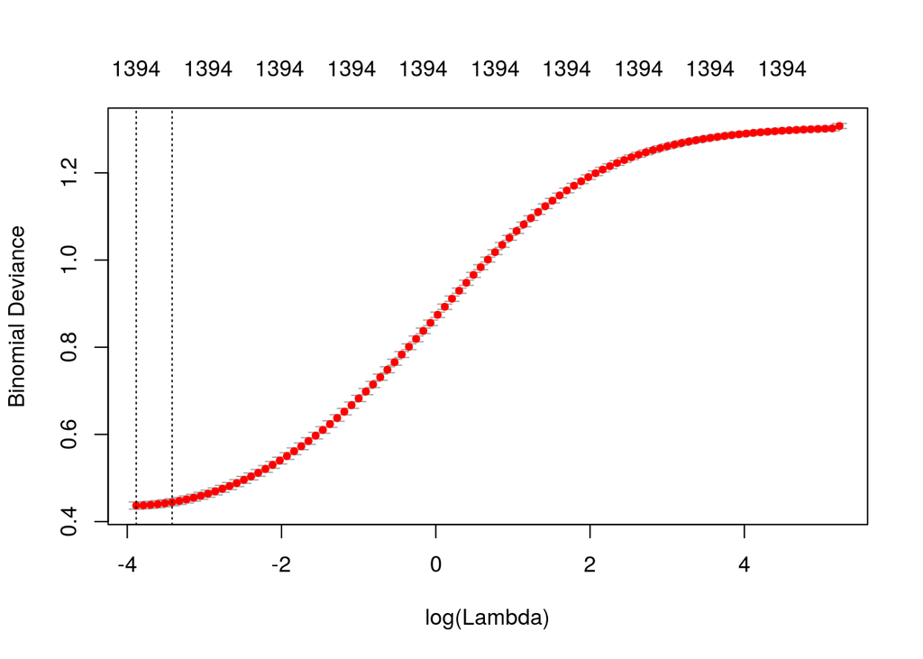

```r
library(glmnet)
require(doMC)
registerDoMC(cores=3)
ridge <- cv.glmnet(twdfm[training,], tweets$trump[training],
    family="binomial", alpha=0, nfolds=5, parallel=TRUE,
    type.measure="deviance")
plot(ridge)
```

We can now compute the performance metrics on the test set.

```r
## function to compute accuracy
accuracy <- function(ypred, y){
    tab <- table(ypred, y)
    return(sum(diag(tab))/sum(tab))
}
# function to compute precision
precision <- function(ypred, y){
    tab <- table(ypred, y)
    return((tab[2,2])/(tab[2,1]+tab[2,2]))
}
# function to compute recall
recall <- function(ypred, y){
    tab <- table(ypred, y)
    return(tab[2,2]/(tab[1,2]+tab[2,2]))
}
# computing predicted values
preds <- predict(ridge, twdfm[test,], type="response") > mean(tweets$trump[test])
# confusion matrix
table(preds, tweets$trump[test])
```

```
##
## preds      0    1
##   FALSE 1181   54
##   TRUE    93  677
```

```r
# performance metrics
accuracy(preds, tweets$trump[test])
```

```
## [1] 0.9266833
```

```r
precision(preds, tweets$trump[test])
```

```
## [1] 0.8792208
```

```r
recall(preds, tweets$trump[test])
```

```
## [1] 0.9261286
```

Something that is often very useful is to look at the actual estiamted coefficients and see which of these have the highest or lowest values:

```r
# from the different values of lambda, let's pick the best one
best.lambda <- which(ridge$lambda==ridge$lambda.min)
beta <- ridge$glmnet.fit$beta[,best.lambda]
head(beta)
```

```
##          @       will      trump      great      thank    america
## -0.6568460 -0.4763454 -1.0495392 -0.9517421 -0.3899949 -0.5320853
```

```r
## identifying predictive features
df <- data.frame(coef = as.numeric(beta),
                word = names(beta), stringsAsFactors=F)

df <- df[order(df$coef),]
head(df[,c("coef", "word")], n=30)
```

```
##           coef                             word
## 812  -2.946053                    entrepreneurs
## 1119 -2.780045                          stopped
## 1291 -2.431947 #trump2016#makeamericagreatagain
## 1195 -2.422461                       #wiprimary
## 1265 -2.413748                         register
## 1289 -2.365488                          muslims
## 13   -2.244013           #makeamericagreatagain
## 1124 -2.224513                              son
## 1365 -2.211081                        louisiana
## 1099 -2.162391                        desperate
## 1215 -2.147966                          changed
## 867  -2.109633                                c
## 1363 -2.061911                            wayne
## 1216 -2.056875                             mark
```

[output cut: 16 more lines]

```r
paste(df$word[1:30], collapse=", ")
```

[output not shown]

```r
df <- df[order(df$coef, decreasing=TRUE),]
head(df[,c("coef", "word")], n=30)
```

```
##          coef                    word
## 932  2.833202                   admin
## 54   2.791958             #choosecruz
## 749  2.789096                   heidi
## 1378 2.740852                  prayer
## 1287 2.705626              #cruzcrowd
## 374  2.696764          #atimefortruth
## 1329 2.670115                   human
## 129  2.666027          #caucusforcruz
## 1343 2.497244                  ensure
## 979  2.492870                 houston
## 1040 2.457241               #kateslaw
## 709  2.451043                   y'all
## 916  2.443296           #believeagain
## 1188 2.423531                   catch
```

[output cut: 16 more lines]

```r
paste(df$word[1:30], collapse=", ")
```

[output not shown]